# ANZ_Module_2_Predictive Analytics

Chanyanart KiattipornOpas

11/21/2021

# About the Task

This task focus on **Predictive Analysis** aim to predict **The Annual Salary** of each customers.

Explore correlations between annual salary and various customer attributes (e.g. age). These attributes could be those that are readily available in the data (e.g. age) or those that you construct or derive yourself (e.g. those relating to purchasing behaviour). Visualise any interesting correlations using a scatter plot.

Build a simple regression model to predict the annual salary for each customer using the attributes you identified above

How accurate is your model?

For a challenge: build a decision-tree based model to predict salary. Does it perform better? How would you accurately test the performance of this model?

# Preparation

## 1. Download Library

```r
library(tidyverse)
library(readxl)
library(corrplot)
library(rpart)
```

## 2. Import Data into Rstudio

```r
transac <- read_csv("ANZ_clean_data.csv")
```

## 3. Planning for Analysis

Predict “Annual Salary” (Y) by using these attributes:

```
- Age
- Pay Frequency
- Frequency of Sales Transaction
- Mean of Sales Transaction across 3 months
- Highest price of Sales Transaction
- Median Balance
```

```r
# Create the New List for each Customers by id

customers <- transac %>%
                select(customer_id, age) %>%
                group_by(customer_id) %>%
                distinct() %>%
                as.data.frame()

head(customers)
```

|  | customer_id | age |
| --- | --- | --- |
| 1 | CUS-2487424745 | 26 |
| 2 | CUS-2142601169 | 38 |
| 3 | CUS-1614226872 | 40 |
| 4 | CUS-2688605418 | 20 |
| 5 | CUS-4123612273 | 43 |
| 6 | CUS-3026014945 | 27 |

# Derive the attributes from Data

## 1. Salary

```r
# Extract only PAY/SALARY transaction type.

pay_salary <- transac %>%
    select(customer_id,
           txn_description,
           date,
           amount) %>%
    filter(txn_description == "PAY/SALARY") %>%
    group_by(customer_id) %>%
    as.data.frame()

head(pay_salary)
```

|  | customer_id | txn_description | date | amount |
| --- | --- | --- | --- | --- |
| 1 | CUS-1462656821 | PAY/SALARY | 2018-08-01 07:00:00 | 3903.95 |
| 2 | CUS-2500783281 | PAY/SALARY | 2018-08-01 07:00:00 | 1626.48 |
| 3 | CUS-326006476 | PAY/SALARY | 2018-08-01 07:00:00 | 983.36 |
| 4 | CUS-1433879684 | PAY/SALARY | 2018-08-01 07:00:00 | 1408.08 |
| 5 | CUS-4123612273 | PAY/SALARY | 2018-08-01 07:00:00 | 1068.04 |
| 6 | CUS-2487424745 | PAY/SALARY | 2018-08-01 07:00:00 | 1013.67 |

## 2. Pay Frequency

```r
pay_salary$date <- as.Date(pay_salary$date)

# How many time of each customers got paid in this 3 months?

pay_freq <- pay_salary %>%
    group_by(customer_id) %>%
    count(amount) %>%
    as.data.frame()

# rename columns
colnames(pay_freq)[3] <- "pay_frequent"

tail(pay_freq)
```

|  | customer_id | amount | pay_frequent |
| --- | --- | --- | --- |
| 95 | CUS-586638664 | 1952.29 | 6 |
| 96 | CUS-72755508 | 725.32 | 12 |
| 97 | CUS-809013380 | 1037.07 | 13 |
| 98 | CUS-860700529 | 1808.62 | 6 |
| 99 | CUS-880898248 | 1433.98 | 6 |
| 100 | CUS-883482547 | 3977.46 | 7 |

## 3. Annual Salary (Y)

```r
# Total Salary across 3 months

total_3m_salary <- pay_freq %>%
    mutate(threeM_salary = amount*pay_frequent)

head(total_3m_salary)
```

|  | customer_id | amount | pay_frequent | threeM_salary |
| --- | --- | --- | --- | --- |
| 1 | CUS-1005756958 | 970.47 | 13 | 12616.11 |
| 2 | CUS-1117979751 | 3578.65 | 7 | 25050.55 |
| 3 | CUS-1140341822 | 1916.51 | 6 | 11499.06 |
| 4 | CUS-1147642491 | 1711.39 | 13 | 22248.07 |
| 5 | CUS-1196156254 | 3903.73 | 7 | 27326.11 |
| 6 | CUS-1220154422 | 2282.36 | 7 | 15976.52 |

Three months is one Quater, so 1 year = 4 quaters

```r
# Calculate Annual Salary

annual_salary <- total_3m_salary %>%
    mutate(annual_salary = threeM_salary*4)

# rename columns
colnames(annual_salary)[2] <- "salary"

tail(annual_salary)
```

|  | customer_id | salary | pay_frequent | threeM_salary | annual_salary |
| --- | --- | --- | --- | --- | --- |
| 95 | CUS-586638664 | 1952.29 | 6 | 11713.74 | 46854.96 |
| 96 | CUS-72755508 | 725.32 | 12 | 8703.84 | 34815.36 |
| 97 | CUS-809013380 | 1037.07 | 13 | 13481.91 | 53927.64 |
| 98 | CUS-860700529 | 1808.62 | 6 | 10851.72 | 43406.88 |
| 99 | CUS-880898248 | 1433.98 | 6 | 8603.88 | 34415.52 |
| 100 | CUS-883482547 | 3977.46 | 7 | 27842.22 | 111368.88 |

```r
customers <- customers %>%
    inner_join(annual_salary, by = "customer_id")

tail(customers)
```

|  | customer_id | age | salary | pay_frequent | threeM_salary | annual_salary |
| --- | --- | --- | --- | --- | --- | --- |
| 95 | CUS-134833760 | 52 | 3785.78 | 7 | 26500.46 | 106001.84 |
| 96 | CUS-2505971401 | 40 | 1946.57 | 13 | 25305.41 | 101221.64 |
| 97 | CUS-2819545904 | 42 | 3231.26 | 7 | 22618.82 | 90475.28 |
| 98 | CUS-3395687666 | 42 | 1757.81 | 6 | 10546.86 | 42187.44 |
| 99 | CUS-1147642491 | 34 | 1711.39 | 13 | 22248.07 | 88992.28 |
| 100 | CUS-261674136 | 29 | 4405.30 | 7 | 30837.10 | 123348.40 |

## 4. Frequency / Mean / Highest price of Sales Transaction across 3 months

```r
sale_transac <- transac %>% select(customer_id,
                            txn_description,
                            amount) %>%
            filter(txn_description == "POS" |
                     txn_description == "SALES-POS") %>%
            group_by(customer_id) %>%
            summarise(transac_freq = length(customer_id),
                      sum_amount = sum(amount),
                      mean_amount = mean(amount),
                      highest_amount= max(amount))

head(sale_transac)
```

| customer_id | transac_freq | sum_amount | mean_amount | highest_amount |
| --- | --- | --- | --- | --- |
| CUS-1005756958 | 48 | 1810.86 | 37.72625 | 226.82 |
| CUS-1117979751 | 52 | 3975.82 | 76.45808 | 2885.85 |
| CUS-1140341822 | 65 | 4389.54 | 67.53138 | 1271.46 |
| CUS-1147642491 | 76 | 3885.75 | 51.12829 | 432.92 |
| CUS-1196156254 | 163 | 4940.61 | 30.31049 | 390.67 |
| CUS-1220154422 | 48 | 3164.59 | 65.92896 | 168.74 |

```r
customers <- customers %>%
    inner_join(sale_transac, by = "customer_id")

head(customers)
```

|  | customer_id | age | salary | pay_frequent | threeM_salary | annual_salary | transac_freq | sum_amount | mean_amount | highest_amount |
| --- | --- | --- | --- | --- | --- | --- | --- | --- | --- | --- |
| 1 | CUS-2487424745 | 26 | 1013.67 | 14 | 14191.38 | 56765.52 | 531 | 9819.21 | 18.49192 | 1452.21 |
| 2 | CUS-2142601169 | 38 | 1002.13 | 13 | 13027.69 | 52110.76 | 276 | 9685.76 | 35.09333 | 2349.55 |
| 3 | CUS-1614226872 | 40 | 892.09 | 13 | 11597.17 | 46388.68 | 220 | 6845.27 | 31.11486 | 235.36 |
| 4 | CUS-2688605418 | 20 | 2320.30 | 6 | 13921.80 | 55687.20 | 101 | 4109.44 | 40.68752 | 444.28 |
| 5 | CUS-4123612273 | 43 | 1068.04 | 14 | 14952.56 | 59810.24 | 85 | 4940.56 | 58.12424 | 760.27 |
| 6 | CUS-3026014945 | 27 | 2840.15 | 7 | 19881.05 | 79524.20 | 248 | 6532.29 | 26.33988 | 385.87 |

## 5. Balance

```r
med_balance <- transac %>% select(customer_id,
                            balance) %>%
                  group_by(customer_id) %>%
            summarise(median_balance = median(balance))
```

```r
customers <- customers %>%
    inner_join(med_balance, by = "customer_id") %>%
    as_tibble()

head(customers)
```

| customer_id | age | salary | pay_frequent | threeM_salary | annual_salary | transac_freq | sum_amount | mean_amount | highest_amount | median_balance |
| --- | --- | --- | --- | --- | --- | --- | --- | --- | --- | --- |
| CUS-2487424745 | 26 | 1013.67 | 14 | 14191.38 | 56765.52 | 531 | 9819.21 | 18.49192 | 1452.21 | 1580.400 |
| CUS-2142601169 | 38 | 1002.13 | 13 | 13027.69 | 52110.76 | 276 | 9685.76 | 35.09333 | 2349.55 | 1132.660 |
| CUS-1614226872 | 40 | 892.09 | 13 | 11597.17 | 46388.68 | 220 | 6845.27 | 31.11486 | 235.36 | 3618.500 |
| CUS-2688605418 | 20 | 2320.30 | 6 | 13921.80 | 55687.20 | 101 | 4109.44 | 40.68752 | 444.28 | 5616.630 |
| CUS-4123612273 | 43 | 1068.04 | 14 | 14952.56 | 59810.24 | 85 | 4940.56 | 58.12424 | 760.27 | 6162.450 |
| CUS-3026014945 | 27 | 2840.15 | 7 | 19881.05 | 79524.20 | 248 | 6532.29 | 26.33988 | 385.87 | 5893.355 |

# Correlation

```r
cor_matrix <- customers %>%
                select(annual_salary,
                       age,
                       pay_frequent,
                       transac_freq,
                       mean_amount,
                       highest_amount,
                       median_balance) %>%
                cor()
```

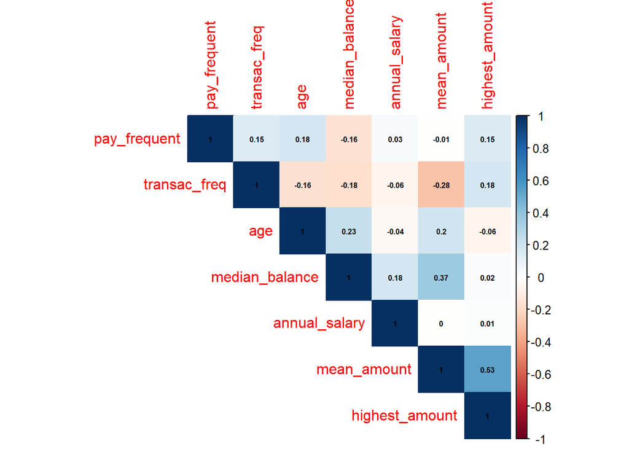

```r
# Visualize

corrplot(cor_matrix,
         method = "color",
         type="upper",
         addCoef.col = "black", number.cex = 0.5,
         order = "hclust")
```

# Check Complete Observation

```r
mean(complete.cases(customers))
```

```
## [1] 1
```

1 means all observations has no NULL value. All data are completed.

# Prediction Model

```r
# Split data

set.seed(21)
n <- nrow(customers)
id <- sample(1:n, size = n*0.8)
train_data <- customers[id, ]
test_data <- customers[-id, ]
```

## 1. Linear Regression Model

### 1.1 Train Model

```r
lmModel <- lm(annual_salary ~ age +
                              pay_frequent +
                              transac_freq +
                              mean_amount +
                              highest_amount +
                              median_balance,
              data = train_data)

lmModel
```

```
##
## Call:
## lm(formula = annual_salary ~ age + pay_frequent + transac_freq +
##     mean_amount + highest_amount + median_balance, data = train_data)
##
## Coefficients:
##    (Intercept)             age    pay_frequent    transac_freq     mean_amount
##     69530.3716       -252.3831        807.8482        -38.3438        -72.2697
## highest_amount  median_balance
##         1.7474          0.3621
```

### 1.2 Score Model (Prediction)

```r
p1 <- predict(lmModel, newdata = test_data)
p1
```

```
##         1         2         3         4         5         6         7         8
##  65326.72 148352.24  70357.52  73520.43  71207.09  64422.20  61986.95  81697.52
##         9        10        11        12        13        14        15        16
##  61310.67  66636.36  69638.32  62921.58  68662.12  60777.08  65135.75  67562.00
##        17        18        19        20
##  69238.98  67918.85  64620.27  61941.98
```

### 1.3 Evaluate Model

```r
error1 <- p1 - test_data$annual_salary
error1
```

```
##          1          2          3          4          5          6          7
##   9639.520  96033.199  11140.441  -4627.006  -1396.874  24995.962  -7309.208
##          8          9         10         11         12         13         14
##   7570.884   2895.952  38012.524  21207.117  12457.143  11999.080  30825.077
##         15         16         17         18         19         20
##  -4140.730  27326.558   4730.576  21623.572  20384.915 -44059.860
```

```r
# RMSE

rmse_test1 <- sqrt(mean(error1**2))
rmse_test1
```

```
## [1] 29121.63
```

## 2. Decision Tree Model

### 2.1 Train Model

```r
rpartModel <- rpart(annual_salary ~ age +
                              pay_frequent +
                              transac_freq +
                              mean_amount +
                              highest_amount +
                              median_balance,
              data = train_data)

rpartModel
```

```
## n= 80
##
## node), split, n, deviance, yval
##       * denotes terminal node
##
##  1) root 80 63262720000  69529.77
##    2) median_balance< 7265.298 37  5645786000  52092.25
##      4) pay_frequent< 6.5 13   318500900  43639.95 *
##      5) pay_frequent>=6.5 24  3895482000  56670.57
##       10) transac_freq< 74.5 9   940774300  49407.77 *
##       11) transac_freq>=74.5 15  2195132000  61028.25 *
##    3) median_balance>=7265.298 43 36685790000  84534.15
##      6) pay_frequent< 6.5 15 11601310000  70901.20 *
##      7) pay_frequent>=6.5 28 20803130000  91837.52
##       14) transac_freq< 29.5 7  6847314000  71977.91 *
##       15) transac_freq>=29.5 21 10274710000  98457.38
##         30) median_balance< 8771.515 7  2600612000  81281.25 *
##         31) median_balance>=8771.515 14  4576391000 107045.50 *
```

### 2.2 Score Model (Prediction)

```r
p2 <- predict(rpartModel, newdata = test_data)
p2
```

```
##         1         2         3         4         5         6         7         8
##  43639.95  70901.20  61028.25  81281.25  49407.77  61028.25  70901.20  71977.91
##         9        10        11        12        13        14        15        16
##  49407.77  49407.77  70901.20  49407.77  49407.77  49407.77  43639.95 107045.45
##        17        18        19        20
##  70901.20  43639.95  43639.95 107045.45
```

### 2.3 Evaluate Model

```r
error2 <- p2 - test_data$annual_salary
error2
```

```
##           1           2           3           4           5           6
## -12047.2492  18582.1627   1811.1733   3133.8057 -23196.1911  21602.0133
##           7           8           9          10          11          12
##   1605.0427  -2148.7257  -9006.9511  20783.9289  22470.0027  -1056.6711
##          13          14          15          16          17          18
##  -7255.2711  19455.7689 -25636.5292  66810.0143   6392.8027  -2655.3292
##          19          20
##   -595.4092   1043.6143
```

```r
# RMSE

rmse_test2 <- sqrt(mean(error2**2))
rmse_test2
```

```
## [1] 20169.15
```

```r
## Compare Prediction Model with RMSE
cat("RMSE of Linear Regression Model: ", rmse_test1,
    "\nRMSE of Decision Tree Model: ", rmse_test2)
```

```
## RMSE of Linear Regression Model:  29121.63
## RMSE of Decision Tree Model:  20169.15
```

# Conclusion

To predict **The Annual Salary** of each customers. We use 6 attributions to predict the annual salary, which are customer’s age, the frequent of salary pay, the median balance of customer’s bank account, the purchasing behaviors(the frequent of buying, the highest and the average amounts of transactions) in this three months.

With 2 Prediction Models that are “Linear Regression Model” and “Decision Tree Model”. As the result, we found that Decision Tree Model is better than Linear Regression Model for this data. We clearly see that RMSE of Decision Tree Model (RMSE: 20169.15) less than Linear Regression Model (RMSE: 29121.63).

However RMSE is more than 20000, that indicates an inaccuracy of the model. The variable may not suit to predict the the Annual Salary, More data and More variable are required to develop the reliable model.